# R Markdown / Vectors / Math Symbols / Dataframes

Sulalitha Bowala

## R Markdown

R Markdown is a powerful document format and authoring framework that combines the benefits of R programming with the simplicity of Markdown syntax to create dynamic and reproducible reports, documents, and presentations. R Markdown files have gained popularity in data analysis, scientific research, and data storytelling due to their versatility and ease of use.

**R Markdown files and their capabilities:**

- Combination of R Code and Text: R Markdown allows you to seamlessly integrate R code and narrative text in a single document. You can write explanations, add headings, and include code chunks, making it easy to describe your data analysis process.
- Reproducibility: One of the key strengths of R Markdown is its ability to create reproducible documents. When you execute R code chunks within an R Markdown document, the output is embedded in the document. This means that others can reproduce your analysis by simply running the same R Markdown file.
- Multiple Output Formats: R Markdown can generate a wide range of output formats, including HTML, PDF, Word documents, presentations (e.g., PowerPoint or Beamer slides), and even interactive web applications. This flexibility makes it suitable for various communication needs.
- Customization: You can customize the appearance and style of your output documents by using various options and templates. This allows you to create professional-looking reports and presentations tailored to your audience.
- Data Visualization: R Markdown supports the creation of data visualizations using R packages like ggplot2. You can embed static or interactive plots directly into your documents, enhancing the presentation of your findings.
- Integration with R Ecosystem: R Markdown seamlessly integrates with the R ecosystem. You can use R packages for statistical analysis, data manipulation, and modeling directly within your document, providing a powerful environment for data analysis and reporting.
- Cross-Platform: R Markdown is cross-platform and can be used on Windows, macOS, and Linux. It’s also compatible with RStudio, a popular integrated development environment (IDE) for R.
- Easy Learning Curve: Learning R Markdown is relatively straightforward, especially if you are already familiar with Markdown syntax. You don’t need advanced programming skills to start creating documents with R Markdown.
- Dynamic Documents: R Markdown documents are dynamic. You can update data, re-run code chunks, and regenerate the entire document with a single click, ensuring that your reports and analyses stay up-to-date.

In summary, R Markdown files are versatile and efficient tools for combining code, data analysis, and narrative text into dynamic and reproducible documents. They are widely used in data science, research, and various fields where data-driven reporting and communication are essential.

As we discussed in class and previous lab, we will produce PDF files using R Markdown files. In the first part of this lab, we discuss how to include text in an Rmd file, change fonts, create sections and subsections, R codes, plots, and write mathematical equations.

### Include a Sentence / Paragraph

Example:

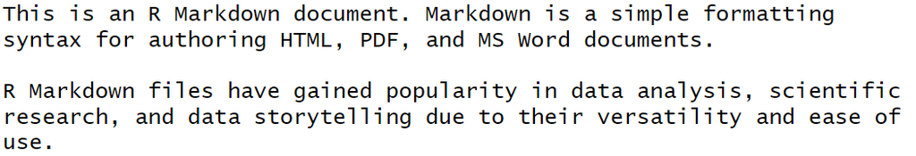

### Make Text Bold

Putting words between two stars creates words in bold.

### Make Text Italic

Putting words between one star creates words in Italic.

Syntax example:

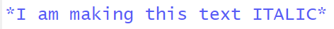

### Create Lists

To create lists, use asterisks, plus signs, or hyphens for bullets, and numbers for ordered lists.

Syntax example:

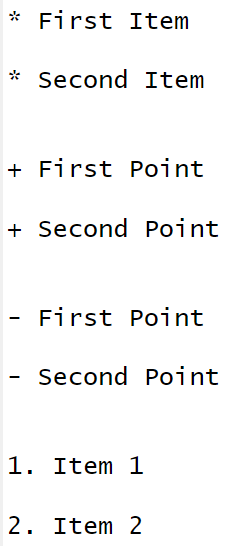

### Comment Text and Codes

- In R and R Markdown, text included between the arrow symbols at either end of this text is recognized as comments that you can only see in the code but not when it compiles.

Syntax example:

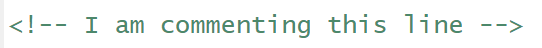

- To add a comment to a specific line of code, simply prefix that line with a # symbol.

Syntax example:

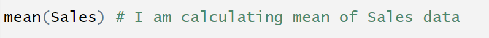

You can easily comment out text/code by highlighting it and selecting “Comment/Uncomment Lines” from the “Code” drop down menu (Shift+Command+C on a Mac).

### Include R codes

To include R code in an R Markdown (Rmd) document, you can use code chunks. Code chunks are delimited by three backticks (```), and you can specify the language (e.g., {r} for R) inside the curly braces.

Example:

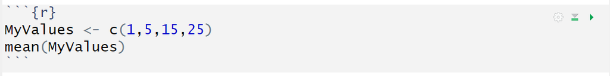

You can run the code chunks interactively within the R Markdown document. In RStudio, you can use the “Run Current Chunk” option (Ctrl + Shift + Enter on Windows/Linux or Command + Shift + Enter on macOS) to execute the code and see the results immediately within the document.

By default, the code and its output will be displayed in the rendered document. You can control the appearance and behavior of code chunks using various chunk options.

For example:

Example:

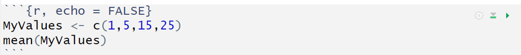

**Note:** You can easily create a R code chunk by first clicking on “Insert a new code chunk (Ctrl+Alt+I)” and then clicking on “Insert a new R chunk”.

[figure not shown]

### Create Sections and Subsections

Double pound signs will make a section heading and three pound signs make a subsection heading.

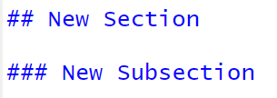

## Vectors

We know from Lab 1 that we can create and save vectors using an assignment arrow (left arrow) and the function “c()”. We also need to name the vector in order it to save in R environment and use it later.

We also can create sequence of integers using the function “c()”.

Example:

```r
MySequence <- c(5:10)
MySequence
```

```
## [1]  5  6  7  8  9 10
```

### Arithmetic on a Single Vector

If we would like to perform an arithmetic operation to **every element** of a vector, we can use basic math functions such +, -, *, and / for addition, subtraction, multiplication, and division.

```r
MySequence+2
```

```
## [1]  7  8  9 10 11 12
```

```r
MySequence-2
```

```
## [1] 3 4 5 6 7 8
```

```r
MySequence*2
```

```
## [1] 10 12 14 16 18 20
```

```r
MySequence/2
```

```
## [1] 2.5 3.0 3.5 4.0 4.5 5.0
```

After performing arithmetic operations, in order to use the new vector in the future, it needs to be saved under a new name (We can use the same name, but it will replace the original vector).

```r
MyNewSequence <- MySequence+2
MyNewSequence
```

```
## [1]  7  8  9 10 11 12
```

In R, you can use the sum() function to calculate the sum of elements in a vector.

```r
Sum_MyNewSequence <- sum(MyNewSequence)
Sum_MyNewSequence
```

```
## [1] 57
```

### Arithmetic on Multiple Vectors

If we have two (or more) vectors of equal length, we can use arithmetic operations on them to perform math component-wise. That means the operations are applied to the first element of each vector, then separately to the second, and again separately to the third, etc…

Example 1: Suppose we have obtained regular working hours and overtime working hours of 5 employees of a company. Regular pay is CAD 15 per hour and overtime pay is 1.5 times the regular pay. We can calculate the total pay for 5 employees as follows.

```r
RegularHours <- c(20, 25, 15, 30, 28)
OvertimeHours <- c(5, 3, 10, 2, 6)
TotalPay <- 15*RegularHours + 1.5*15*OvertimeHours
TotalPay
```

```
## [1] 412.5 442.5 450.0 495.0 555.0
```

Example 2: Suppose you went shopping and bought several items. You know quantities of items you bought and the prices of those items. You may want to know how much you spent on each item.

```r
quantities <- c(3, 2, 1, 4)
prices <- c(10.99, 5.49, 7.99, 2.99)
CostPerItem <- quantities*prices
CostPerItem
```

```
## [1] 32.97 10.98  7.99 11.96
```

## Math Symbols

In R Markdown, you can include various mathematical symbols and equations using LaTeX syntax within your document. LaTeX is a typesetting system commonly used for mathematical and scientific documents.

To include math symbols within the text, you can enclose the LaTeX code within single dollar signs.

Example:

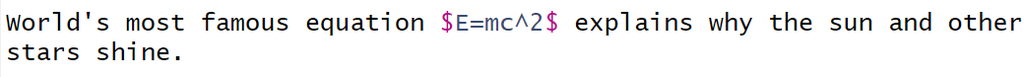

**Output:** World’s most famous equation $E=mc^2$ explains why the sun and other stars shine.

Note: Preview of the equation can we view by bringing the mouse pointer to typed equation.

You can also create a block of math separate from your inline text by putting it between square brackets preceded by backslashes.

Example:

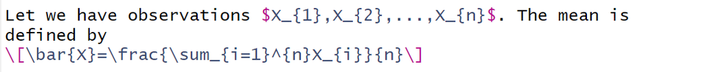

**Output:** Let we have observations $X_{1},X_{2},...,X_{n}$. The mean is defined by
$$\bar{X}=\frac{\sum_{i=1}^{n}X_{i}}{n}$$
.

Differences sources are available to learn more about Latex codes and to produce math symbols and equations (Link: https://rpruim.github.io/s341/S19/from-class/MathinRmd.html)

## Dataframes

### Creating Dataframes

When you create / import a dataset into R, it will take the form of what is called a dataframe. A dataframe is nothing more than a collection of vectors, where each vector is a single column.

In a dataframe, each column represents a variable and each row represents an observation in our dataset. The columns have names associated with them so that we can call upon a specific column by name later.

In the following example, we create a data frame called “my_data” with four columns: “Name”, “Age”, “Gender”, and “Score”.

```r
Name <- c("Alice", "Bob", "Charlie", "David", "Eve")
Age <- c(25, 30, 22, 35, 28)
Gender <- c("Female", "Male", "Male", "Male", "Female")
Score <- c(92, 85, 78, 88, 95)

my_data <- data.frame(Name, Age, Gender, Score)
my_data
```

```
##      Name Age Gender Score
## 1   Alice  25 Female    92
## 2     Bob  30   Male    85
## 3 Charlie  22   Male    78
## 4   David  35   Male    88
## 5     Eve  28 Female    95
```

### Accessing Information in a Dataframe

When we are working with a dataframe, it is possible that we want to look/compute values on a particular row, a particular column, or a particular entry.

- Suppose I want to display all the names in the “my_data” dataframe.

```r
my_data$Name
```

```
## [1] "Alice"   "Bob"     "Charlie" "David"   "Eve"
```

- Suppose I want to calculate the average Age for all the individuals in the “my_data” dataframe.

```r
mean(my_data$Age)
```

```
## [1] 28
```

We can also access particular rows, columns, or cells by attaching two square brackets next to our dataframe’s name and giving a locator.

**Syntax: dataframe_name[row number, column number]**

- Suppose I want to display all the names in the “my_data” dataframe. Note that Name is the first column in my dataframe.

```r
my_data[,1]
```

```
## [1] "Alice"   "Bob"     "Charlie" "David"   "Eve"
```

- Suppose I want to display all the data Bob in the “my_data” dataframe. Note that Bob’s data are in the second row in my dataframe.

```r
my_data[2,]
```

```
##   Name Age Gender Score
## 2  Bob  30   Male    85
```

- Suppose we want to know the Score of Charlie. Note that Charlie’s data are in 3rd row, and Scores are given in 4th column.

```r
my_data[3,4]
```

```
## [1] 78
```